# Functional linear models

## 1. Canadian Weather dataset

We consider again the *Canadian Weather dataset* that is provided by the functional data analysis package `fda`.

This dataset provides data about daily temperature and precipitation at 35 different locations in Canada, averaged over 1960 to 1994. In particular, the R object `CanadianWeather` is a list with the following components:

- `dailyAv`: three dimensional array with dimension 365x35x3, with daily data collected at 35 different weather stations in Canada. The third dimension permits to access the following 3 variables:
  1. `Temperature.C`: daily temperature in Celsius, averaged over 1960 to 1994;
  2. `Precipitation.mm`: daily rainfall in mm, averaged over 1960 to 1994 (rounded to 0.1 mm);
  3. `log10precip`: base 10 logarithm of `Precipitation.mm` (after replacing 27 zeros by 0.05 mm);
- `place`: names of the 35 weather stations in Canada;
- `province`: names of the Canadian provinces of the 35 weather stations;
- `coordinates`: matrix with latitude (`N.latitude`) and longitude (`W.longitude`) of each of the 35 ewather stations;
- `region`: climate zone of the 35 weather stations. Possible values: `Atlantic`, `Pacific`, `Continental` and `Arctic`;
- `monthlyTemp`: matrix of dimension 12x35, with montly average temperatures;
- `monthlyPrecip`: matrix of dimension 12x35, with montly average precipitation;
- `geogindex`: order the weather stations from East to West to North.

```r
require(fda)
data("CanadianWeather")
names(CanadianWeather)
```

```
[1] "dailyAv"       "place"         "province"      "coordinates"   "region"        "monthlyTemp"   "monthlyPrecip" "geogindex"
```

We are interested in studying the **relationship between temperatures and precipitations** in the different Canadian locations, as well as the **relationship between temperatures and climate zones**.

Let’s extract from the list `CanadianWeather` only the variables of interest (daily temperatures and daily log10 precipitations). Remember that we can access each component of a list using the `$` sign, while to access part of an array we can use squared parenteses `[ ]`. In the following code, we first access the three dimensional array `dailyAv` using `CanadianWeather$dailyAv`, then we extract the part of the array corresponding to the variables `Temperature.C` and `log10precip` using `[ , , 'Temperature.C']` and `[ , , 'log10precip']` (note that the first dimension of the array corresponds to the 365 days, the second dimension to the 35 weather stations, and the third to the 3 variables):

```r
temp = CanadianWeather$dailyAv[ , , 'Temperature.C']
prec = CanadianWeather$dailyAv[ , , 'log10precip']
```

We need to create a vector with the time points $t_1,\dots,t_{365}$ corresponding to the daily measurements. Since the range for the time is the interval $[0,365]$ and we have 365 measurements, we can put the time points half-way through a day:

```r
daytime = (1:365) - 0.5
```

Let’s also consider the *annual* log10 precipitations. We don’t have these numbers in the dataset, hence we need to compute them starting from the daily precipitation data:

```r
daily_prec = CanadianWeather$dailyAv[ , , 'Precipitation.mm']
annual_prec = colSums(daily_prec) # compute the sum for each column (i.e. for each of the 35 locations)
annual_prec = log10(annual_prec)  # compute log10
```

Finally, we will also employ the climate zone fo the 35 locations:

```r
region = CanadianWeather$region
```

### Computing curves from raw data

We now **compute curves from raw data** (both for temperatures and log10 precipitations) using the *basis function approach* with *roughness penalty* (see Session 11 and the file `intro FDA.Rmd`). As basis functions $\phi_1(t),\dots,\phi_K(t)$, we employ **Fourier basis** since both our temperature and precipitation data are likely to be periodic curves.

In particular, we first define the range (i.e. the lower and the upper limits) for the values of $t$ where the basis functions will be defined (in our case we have $t \in [0,365]$):

```r
range_day = c(0,365)
```

Then we define a Fourier basis with $K=65$:

```r
fourier_65 = create.fourier.basis(range_day, nbasis = 65)
```

Finally, we employ the function `smooth.basis` (from the package `fda`) on all the 35 locations in our datasets, in order to obtain all the corresponding curves $x_1(t),\dots,x_{35}(t)$ using roughness penalty with the same basis functions, penalty and $\lambda$.

For the temperature curves we use a penalty on the second derivative and $\lambda = 10$ (this is the tuning parameter value we selected using GCV on the Québec temperature curve in Session 11… but note that it would be better to select it using GCV on all curves!):

```
[1] "done"
```

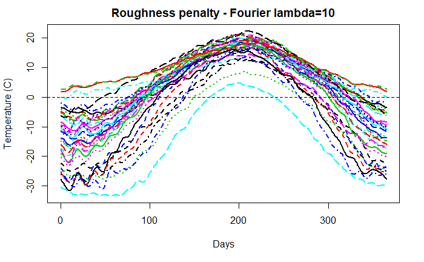

```r
fdPar_fourier_temp = fdPar(fourier_65, 2, lambda = 10)
temp_smooth = smooth.basis(daytime, temp, fdPar_fourier_temp)

plot(temp_smooth, lwd = 2, xlab = 'Days', ylab = 'Temperature (C)', main = 'Roughness penalty - Fourier lambda=10')
```

For the log10 precipitation curves we use a penalty on the second derivative and $\lambda = 10^{6.5}$ (this is the tuning parameter value I selected using GCV on the Montreal log10 precipitation curve in Lab4… but note that it would be better to select it using GCV on all curves!):

```
[1] "done"
```

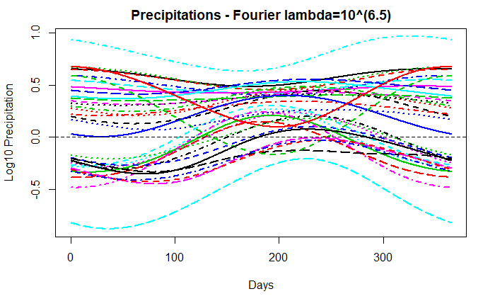

```r
fdPar_fourier_prec = fdPar(fourier_65, 2, lambda = 10^(6.5))
prec_smooth = smooth.basis(daytime, prec, fdPar_fourier_prec)

plot(prec_smooth, lwd = 2, xlab = 'Days', ylab = 'Log10 Precipitation', main = 'Precipitations - Fourier lambda=10^(6.5)')
```

## 2. Scalar-on-function models

We are interested in studying the **relationship between temperature profiles and annual precipitations**. In order to do that, we can fit a **scalar-on-function model** with response $Y$ the log10 annual precipitation and predictor $x(t)$ the temperature curve:
$$Y = \beta_0 + \int_0^{365} \beta(t)x(t)dt + \varepsilon$$

In order to fit the model (i.e. to estimate the coefficients $\beta_0$ and $\beta(t)$), we will try two different approaches, least squares and roughness penalty. Both approaches are based on the assumption that $\beta(t)$ is a smooth function and represent it using a basis explansion:
$$\beta(t) = \sum_{k=1}^{K} c_k \phi_k(t)$$

In both approaches we will employ the function `fRegress` from the package `fda`. This function requires as input an object `y` containing the response variable (that in our case will be the vector of log10 annual precipitation `annual_prec`), a list `xfdlist` with the intercept and all the predictor variables (in our case, this will be a list with the intercept and the temperature curves) and a list `betalist` (of the same length as `xfdlist`) with the basis functions to be employed for the coefficients.

### Fitting the model using least squares and small $K$

In order to fit the scalar-on-function model using least squares we will employ the function `fRegress` with argument `y = annual_prec`.

The second argument we need is the list `xfdlist` with the intercept and all the predictor variables. We need to have two elements: the first element will be a vector of 1 corresponging to the intercept (vector of length 35, a 1 for each location), while the second element will be a functional object containing our 35 smoothed temperature curves (this is accessible as `temp_smooth$fd`):

```r
temp_list = vector("list", 2) # create a list of length 2
temp_list[[1]] = rep(1, 35)   # vector of 1 of length 35
temp_list[[2]] = temp_smooth$fd
```

The third argument we need is the list `betalist` with the basis functions to be employed for the coefficients. In our case this list has length 2: one element for the intercept coefficient $\beta_0$ and one element for the functional coefficient $\beta(t)$.

For the intercept we employ a constant function on the entire interval $[0,365]$ (since $\beta_0$ doesn’t depend on $t$), that we can create with the function `create.constant.basis` from the package `fda`:

```r
constant = create.constant.basis(range_day)
```

while for the $\beta(t)$ we employ a Fourier basis with a small number of functions $K=5$:

```r
fourier_5 = create.fourier.basis(range_day, nbasis = 5)
```

Let’s now create the list with the basis functions for the coefficients:

```r
beta_list = vector("list", 2)   # create a list of length 2
beta_list[[1]] = constant       # constant basis for beta0
beta_list[[2]] = fourier_5      # Fourier basis with K=5 for beta(t)
```

Finally, we fit our_r functional model with `fRegress`:

```r
model_ls = fRegress(y = annual_prec, xfdlist = temp_list, betalist = beta_list)
```

Let’s now look at the results! The object `model_ls` is a list with a lot of elements, but we will only look at the coefficient estimates $\hat \beta_0$ and $\hat \beta(t)$ that can be found in the elements `betaestlist[[1]]` and `betaestlist[[2]]`, respectively.

The intercept estimate $\hat \beta_0$ is:

```r
model_ls$betaestlist[[1]]$fd$coef
```

```
            [,1]
[1,] 0.009492725
```

While the estimated regression function $\hat \beta(t)$ is:

```
[1] "done"
```

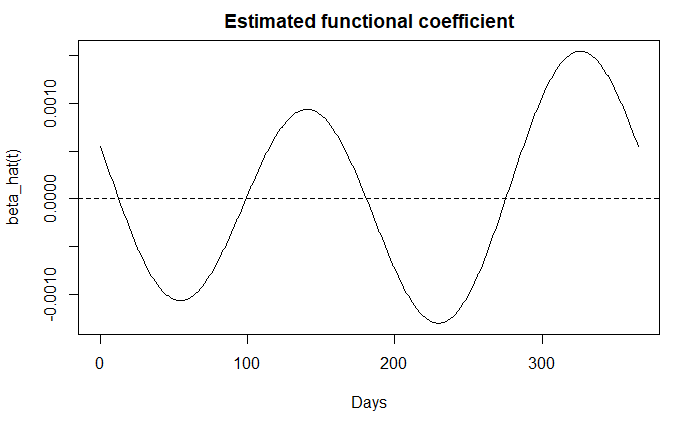

```r
plot(model_ls$betaestlist[[2]], xlab = 'Days', ylab = 'beta_hat(t)', main = 'Estimated functional coefficient')
```

### Fitting the model using roughness penalty

A better way to fit the scalar-on-function model is to use a more complex basis system for $\beta(t)$ and imposing smoothness using **roughness penalty**. To do this we employ again the function `fRegress` with arguments `y = annual_prec` and `xfdlist = temp_list`.

In this case we find $\beta_0$ and $\beta(t)$ minimizing $RSS+\lambda PEN$, where $\lambda$ is the smoothing tuning parameter and the penalty term considers the second derivative of the functional coefficient $\beta(t)$, i.e.
$$PEN = \int{\beta''(t) dt} = \int{ \left( c_1 \phi_1''(t) + \cdots + c_K \phi_K''(t) \right)^2 dt}$$

The third argument `betalist` will need to contain not only the basis functions to be employed for the coefficients, but also the penalty and the tuning parameter $\lambda$ to be used in the penalty for $\beta(t)$.

For the intercept we employ again a constant function on the entire interval $[0,365]$, while for the $\beta(t)$ we employ a Fourier basis with a large number of functions $K=65$, penalty on the second derivative and $\lambda=10^{9.5}$:

```r
fourier_65 = create.fourier.basis(range_day, nbasis = 65)
fdPar_fourier = fdPar(fourier_65, 2, lambda = 10^(9.5))
```

Let’s now create the list with the basis functions for the coefficients:

```r
beta_list_rough = vector("list", 2)   # create a list of length 2
beta_list_rough[[1]] = constant       # constant basis for beta0
beta_list_rough[[2]] = fdPar_fourier      # Fourier basis with K=65 and lambda=10^12 for beta(t)
```

Finally, we fit our functional model with `fRegress`:

```r
model_rough = fRegress(y = annual_prec, xfdlist = temp_list, betalist = beta_list_rough)
```

The intercept estimate $\hat \beta_0$ is:

```r
model_rough$betaestlist[[1]]$fd$coef
```

```
            [,1]
[1,] 0.007938678
```

While the estimated regression function $\hat \beta(t)$ is:

```
[1] "done"
```

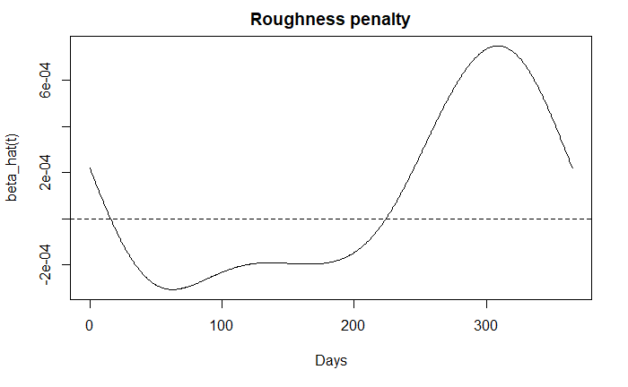

```r
plot(model_rough$betaestlist[[2]], xlab = 'Days', ylab = 'beta_hat(t)', main = 'Roughness penalty')
```

We can observe that the estimated $\hat \beta(t)$ is close to 0 (and quite flat) from the beginning of the year to the end of the Summer, while it has a high positive value in the Fall (aroung day 300). This means that only the autumn months really matter in defining the relationship between temperature curves and annual precipitations.

We could evaluate how good is our model by computing the $R^2$:

```r
annual_prec_hat = model_rough$yhatfdobj
SST = sum((annual_prec - mean(annual_prec))^2)
SSE = sum((annual_prec - annual_prec_hat)^2)
R_squared = (SST - SSE) / SST
R_squared
```

```
[1] 0.7471023
```

Our model (i.e. the relationship with the temperature profiles) explains 74.7% of the variability in the annual precipitations!

Note that in this example we used a specific value of $\lambda$, but in general we should select $\lambda$ using cross-validation (see FDA book 9.4.3).

## 3. Function-on-scalar models

We are interested in studying the **relationship between temperature profiles and climate zones**. In order to do that, we can fit a **function-on-scalar model** with response $y(t)$ the temperature curve and predictor the categorical variable reporting the region (i.e. the climate zone). Since we have 4 regions (Atlantic, Pacific, Continental and Artic), we will have 3 dummy variables $X_{d1}, X_{d2}, X_{d3}$:
$$y(t) = \beta_0(t) + \beta_1(t)X_{d1} + \beta_2(t)X_{d2} + \beta_3(t)X_{d3} + \varepsilon(t)$$

We will only show an example of fitting the model using **roughness panalty**. This is done using again the function `fRegress` from the package `fda` (the same function can be used for the least squares approach).

The first argument we need is an object `y` containing the functional response. In out case this will be a functional object containing our 35 smoothed temperature curves (this is accessible as `temp_smooth$fd`).

The second argument we need is the list `xfdlist` with the intercept and all the predictor variables. We need to have four elements: the first element will be a vector of 1 corresponging to the intercept (vector of length 35, a 1 for each location), while the other three elements will be a vector of 0 and 1 corresponding to each of the three dummy variables. Let’s create it:

```r
region_list = vector("list", 4)   # create a list of length 4
region_list[[1]] = rep(1, 35)     # vector of 1 of length 35

# first dummy variable, corresponding to Pacific region
region_list[[2]] = rep(0, 35)     # vector of 0 of length 35
region_list[[2]][which(region == 'Pacific')] = 1 # put a 1 when the location is in the Pacific region

# second dummy variable, corresponding to Continental region
region_list[[3]] = rep(0, 35)     # vector of 0 of length 35
region_list[[3]][which(region == 'Continental')] = 1 # put a 1 when the location is in the Continental region

# third dummy variable, corresponding to Artic region
region_list[[4]] = rep(0, 35)     # vector of 0 of length 35
region_list[[4]][which(region == 'Arctic')] = 1 # put a 1 when the location is in the Arctic region
```

The third argument `betalist` will need to contain the basis functions to be employed for each coefficient $\beta_j(t)$, the penalty and the tuning parameter $\lambda$.

```r
fourier_65 = create.fourier.basis(range_day, nbasis = 65)
fdPar_fourier = fdPar(fourier_65, 2, lambda = 10^4)
```

Let’s now create the list with the basis functions for the coefficients:

```r
beta_list_rough = vector("list", 4)   # create a list of length 4
beta_list_rough[[1]] = fdPar_fourier  # Fourier basis with K=65 for beta_0(t)
beta_list_rough[[2]] = fdPar_fourier  # Fourier basis with K=65 for beta_1(t)
beta_list_rough[[3]] = fdPar_fourier  # Fourier basis with K=65 for beta_2(t)
beta_list_rough[[4]] = fdPar_fourier  # Fourier basis with K=65 for beta_3(t)
```

Finally, we fit our functional model with `fRegress`:

```r
model_rough = fRegress(y = temp_smooth$fd, xfdlist = region_list, betalist = beta_list_rough)
```

We can look at the estimated regression functions $\hat \beta_j(t)$:

```r
par(mfrow = c(2,2))

plot(model_rough$betaestlist[[1]], xlab = 'Days', ylab = 'beta0_hat(t)', main = 'Atlantic region')
```

```
[1] "done"
```

```r
plot(model_rough$betaestlist[[2]], xlab = 'Days', ylab = 'beta1_hat(t)', main = 'Pacific region')
```

```
[1] "done"
```

```r
plot(model_rough$betaestlist[[3]], xlab = 'Days', ylab = 'beta2_hat(t)', main = 'Continental region')
```

```
[1] "done"
```

```
[1] "done"
```

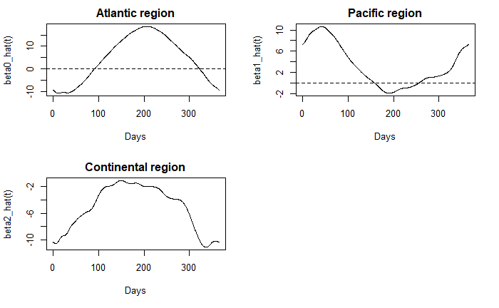

```r
plot(model_rough$betaestlist[[4]], xlab = 'Days', ylab = 'beta3_hat(t)', main = 'Arctic region')
```

[output not shown]

The $\hat \beta_0(t)$, i.e. the coefficient for the Atlantic region that is our baseline, tells us that the locations in the Atlantic regions generally have cold Winter (average temperature around -10), then the tempertature increases during the Spring to reach about 20 in the middle of the Summer, and then it decreases in the Fall.

## 4. Function-on-function models

In order to fit the model (i.e. to estimate the coefficients $\beta_0(t)$ and $\beta(s,t)$), we use roughness panalty. This approach is based on the assumption that $\beta_0(t)$ and $\beta(s,t)$ are smooth functions and represent them using a basis explansion:
$$\beta_0(t) = \sum_{k=1}^{K_0} c_k \phi_{0,k}(t)$$
$$\beta(s,t) = \sum_{k=1}^{K_1} \sum_{l=1}^{K_2} b_{l,k} \phi_k(s) \psi_l(t)$$

The third argument `betaList` will need to contain two elements: the basis functions to be employed for $\beta_0(t)$ and the bivariate basis function to be employed for the bivariate coefficient $\beta(s,t)$ (each with its penalty and tuning parameter $\lambda$).

```r
fourier_65 = create.fourier.basis(range_day, nbasis = 65)
fdPar_beta0 = fdPar(fourier_65, 2, lambda = 10)
```

For $\beta(s,t)$ we will employ the same Fourier basis with a large number of functions $K=65$ in both directions $s$ and $t$, penalty on the second derivative and $\lambda=100$. In order to define a bivariate basis system we use the function `bifd`:

```r
fourier_bi_65  = bifd(matrix(0, nrow = 65, ncol = 65), sbasisobj = fourier_65, tbasisobj = fourier_65)
bifdPar_beta = bifdPar(fourier_bi_65, 2, 2, lambdas = 100, lambdat = 100)
```

Let’s now create the list with the basis functions for the coefficients:

```r
beta_list_rough = vector("list", 2)   # create a list of length 2
beta_list_rough[[1]] = fdPar_fourier  # Fourier basis with K=65 for beta_0(t)
beta_list_rough[[2]] = bifdPar_beta   # bivariate Fourier basis with K=65 for beta(s,t)
```

Finally, we fit our functional model with `linmod`:

```r
model_rough = linmod(xfdobj = prec_smooth$fd, yfdobj = temp_smooth$fd, betaList = beta_list_rough)
```

Let’s visualize the estimated coefficient $\beta_0(t)$:

```
[1] "done"
```

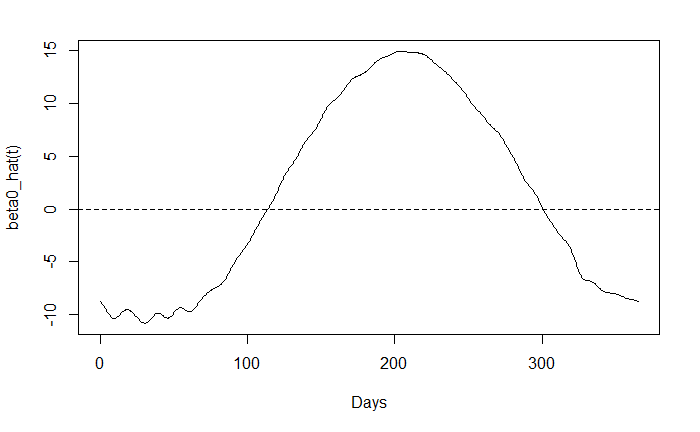

```r
plot(model_rough$beta0estfd, xlab = 'Days', ylab = 'beta0_hat(t)')
```

Finally, let’s visualize the estimated bivariate coefficient $\beta(s,t)$:

```r
require(rgl)

time = seq(0, 365, by=5)
beta1_matrix = eval.bifd(time, time, model_rough$beta1estbifd)

open3d()
persp3d(time, time, beta1_matrix, col = "lightblue", xlab = 'Days', ylab = 'Days', zlab  = 'beta(s,t)')
```

[output not shown]